# PST.RGT.hybrids

Sarah Mueller

2025-06-16

## Load genome information.

```r
category <- read.delim("/dss/dsslegfs01/pr53da/pr53da-dss-0034/projects/2021_SwallowRRBS/0_Pre-processing/4_methyl_calling/1_CpG_islands/168.20miss/homer.cpgi.prop.168.merged.20miss.rmlowv.rmout.txt", header=T)

#separate chr and pos columns
category <- category %>%
  separate(loci.id, into = c("chr", "pos"), sep = "_", remove = FALSE) %>%
  distinct(chr, pos, .keep_all = TRUE) %>%
  mutate(pos = as.numeric(pos))

#get rid of leading and trailing white spaces
category$category <- trimws(category$category)

#specify region
category <- category %>%
  mutate(region = sub("_.*", "", category))
```

## Load PST information for the parental population comparisons for the hybrid zone

Looking at highest PST differences between RGT and looking at these sites in hybrids

```r
pst_site <- read.table("/dss/dsslegfs01/pr53da/pr53da-dss-0034/projects/2021_SwallowRRBS/2_Divergence/1_PST/0_cpgi_pst/0_pst_cpgi_c05.txt", header=T)

pst_RGT <- pst_site %>% dplyr::select(site.id, gutturalis.vs.rustica.r.pst, gutturalis.vs.tytleri.pst, rustica.r.vs.tytleri.pst)

# Reshape the PST data into long form
pst_RGT_long <- pst_RGT %>%
  pivot_longer(-site.id, names_to = "comparison", values_to = "pst") %>%
  drop_na() %>%
  separate(comparison, into = c("pop1", "pop2"), sep = "\\.vs\\.") %>%
  mutate(pop2 = gsub("\\.pst$", "", pop2))


#Grab only top 1% of PST loci
pst_rt <- pst_RGT_long %>%
  filter(pop1 == "rustica.r", pop2 == "tytleri") %>%
  arrange(desc(pst)) %>%
  mutate(rank = row_number()) %>%
  filter(pst >= quantile(pst, 0.99, na.rm = TRUE))
```

## Load methylation data

```r
prop.hyb <- read.delim("/dss/dsslegfs01/pr53da/pr53da-dss-0034/projects/2021_SwallowRRBS/0_Pre-processing/4_methyl_calling/1_CpG_islands/168.20miss/homer.cpgi.prop.168.merged.20miss.rmlowv.rmout.txt", header=T)

pst_rt <- left_join(pst_rt, prop.hyb, by = c("site.id" = "region.id"))


# Remove "ME_" from the start of any column name in pst_rg
colnames(pst_rt) <- gsub("^ME_", "", colnames(pst_rt))
```

## Load introgress information as this will allow us to better define hybrids and parentals than just population assignment

```r
#Load in introgress results
rt_admix <- read.table("/dss/dsslegfs01/pr53da/pr53da-dss-0034/projects/2021_SwallowRRBS/5_WGS/2_hybrid_index/2_newhybrids/RT_hyb/2_output_classes.txt", header=T)

#Define based on classes from New Hybrids
par.R <- rt_admix %>% filter(Assigned_Class == "R", grepl("_R_", Individual))
par.T <- rt_admix %>% filter(Assigned_Class == "T", grepl("_T_", Individual))
hyb.RT <- rt_admix %>% filter(Assigned_Class == "F1")
```

## Grab high PST loci for the RT comparison

```r
# Define population groups based on the id column of three dataframes
population_groups <- list(
  Rr = par.R$Individual,
  T = par.T$Individual,
  RT = hyb.RT$Individual
)

# Calculate the mean and variance for each population group
population_stats <- sapply(names(population_groups), function(pop) {
  # Get the IDs for the current population group
  ids <- population_groups[[pop]]

  # Check if the IDs exist as columns in pst_rt
  cols <- intersect(ids, colnames(pst_rt))

  if (length(cols) == 0) return(NULL) # If no columns match, return NULL

  # Compute row means and variances
  means <- apply(pst_rt[, cols, drop = FALSE], 1, function(x) mean(x, na.rm = TRUE))
  vars  <- apply(pst_rt[, cols, drop = FALSE], 1, function(x) var(x, na.rm = TRUE))

  # Return a matrix with mean and variance as separate columns
  cbind(means, vars)
}, simplify = FALSE)

# Combine results into a single data.frame
population_stats_df <- do.call(cbind, lapply(names(population_stats), function(pop) {
  out <- population_stats[[pop]]
  if (is.null(out)) return(NULL)
  colnames(out) <- c(pop, paste0(pop, ".var"))
  out
}))

pst_prop_rt <- cbind(pst_rt, population_stats_df)

pst_prop_rt <- pst_prop_rt %>% filter(!if_all(contains("_ADL_"), is.na))
#ONLY 1084 sites present in hybrids also with missing data below 20%

pst_prop_rt <- pst_prop_rt %>%
  dplyr::select(!contains("DE_") & !contains("CH_") & !contains("FI_") & !contains("_G_") & !contains("_RG_"))
```

## Test for differences between the parental and hybrid means

I want to test if the parents and hybrids differ significantly from eachother.

```r
R_names <- par.R$Individual
T_names <- par.T$Individual
RT_names <- hyb.RT$Individual

# Map individual names to their population assignments
# We create a dataframe that maps each individual column name to its population.
individual_to_pop <- tibble(
  individual = c(R_names, T_names, RT_names),
  population = c(
    rep("R", length(R_names)),
    rep("T", length(T_names)),
    rep("RT", length(RT_names))
  )
)
```

## Reshape the data for ANOVA

I need to transform the data from a wide format (one column per individual) to a long format (one column for measurements, one for population). I’ll only select columns that represent individuals. These are columns containing “*ADL*” in their names.

```r
pheno_cols <- names(pst_prop_rt)[grepl("_ADL_", names(pst_prop_rt))]
##needed if testing subests
final_cols <- pheno_cols[pheno_cols %in% individual_to_pop$individual]

long_data <- pst_prop_rt %>%
  dplyr::select(site.id, all_of(final_cols)) %>%
  pivot_longer(
    cols = -site.id,
    names_to = "individual",
    values_to = "phenotype_value"
  ) %>%
  # Now, join the phenotypic data with the population data.
  left_join(individual_to_pop, by = "individual") %>%
  # We need to make sure 'population' is a factor for statistical testing.
  mutate(population = as.factor(population))

long_data$population[is.na(long_data$population)] <- "RT"
```

## Perform the ANOVA and Tukey HSD test for each site

Use the nest approach to run the ANOVA and possible Tukey test to each site.

```r
# Group the long data by site.id
nested_data <- long_data %>%
  group_by(site.id) %>%
  nest()

# Create a function to perform the analysis
run_anova_and_tukey <- function(df) {
  # Perform one-way ANOVA
  anova_model <- aov(phenotype_value ~ population, data = df)

  # Use broom::tidy to get a clean dataframe of all ANOVA results
  anova_results <- tidy(anova_model)

  # Only run Tukey's test if the ANOVA is significant (e.g., p < 0.05).
  # This is a standard practice to avoid false positives.
  anova_p_value <- anova_results$p.value[1]

  if (anova_p_value < 0.05) {
    # Perform Tukey-Kramer HSD post-hoc test
    tukey_test <- TukeyHSD(anova_model)

    #Convert to dataframe
    tukey_df <- as.data.frame(tukey_test$population) %>%
    tibble::rownames_to_column(var = "comparison") %>%
    dplyr::rename(p_value_adjusted = `p adj`)

    # Store the results and return them
    return(list(
      anova_results = anova_results,
      tukey_results = tukey_df # 'tidy' makes it a clean dataframe
    ))
  } else {
    # If ANOVA is not significant, return a message for the Tukey results
    return(list(
      anova_results = anova_results,
      tukey_results = "Not significant"
    ))
  }
}

# Apply the function to each nested dataframe (each site)
results <- nested_data %>%
  mutate(analysis = map(data, run_anova_and_tukey)) %>%
  # Remove the 'data' column to keep the output clean
  dplyr::select(site.id, analysis)
```

## Clean results

```r
#Unnest to retrieve summary
final_anova_results <- results %>%
  mutate(anova_summary = map(analysis, "anova_results")) %>%
  dplyr::select(site.id, anova_summary) %>%
  unnest(cols = anova_summary) %>%
  # Filter to show only the row with the population statistics
  filter(term == "population") %>%
  # Rename columns for clarity using dplyr::rename as requested by the user.
  dplyr::rename(
    df = df,
    sum_sq = sumsq,
    mean_sq = meansq,
    f_statistic = statistic,
    p_value = p.value
  ) %>%
  dplyr::select(site.id, df, f_statistic, p_value)

#See how many sites/regions are significant
site_summary <- final_anova_results %>%
  mutate(location_type = if_else(
    str_count(site.id, "_") == 2,
    "region",
    "site"
  ))

# 2. Summary to see the counts of each
site_summary %>%
  filter(p_value < 0.05) %>%
  group_by(location_type) %>%
  summarise(count = n())
```

```
## # A tibble: 2 × 2
##   location_type count
##   <chr>         <int>
## 1 region          185
## 2 site            744
```

```r
#Extract the Tukey results

#Filter to keep only rows where the Tukey results are significant
significant_tukey <- results %>%
  filter(map_lgl(analysis, ~ is.data.frame(.$tukey_results)))

#Extract dataframe
final_tukey_list <- set_names(
  map(significant_tukey$analysis, "tukey_results"),
  significant_tukey$site.id
)
```

##Clean Tukey Results

I want to make the Tukey results more readable, so I convert them into a dataframe instead of a list

```r
#This function takes the Tukey data frame for a single site and reshapes it.
process_tukey_df <- function(df) {
  # Add the 'comparison' column to the row names
  df_wide <- df %>%
    tibble::column_to_rownames("comparison")

  # Reshape the data frame from long to wide format
  # The 'comparison' row names become the prefixes for the new columns
  df_wide <- as.data.frame(t(df_wide))
  df_wide <- tibble::rownames_to_column(df_wide, var = "metric")

  # Pivot the data frame to have the comparisons as part of the column names
  df_wide <- df_wide %>%
    pivot_wider(names_from = metric, values_from = everything())

  # Clean up column names to match the requested format (e.g., R_G_diff)
  # The 'names_prefix' argument from pivot_wider handles this automatically.

  return(df_wide)
}

# Apply the function to each data frame in the list
wide_tukey_list <- map(final_tukey_list, process_tukey_df)
```

Look at which sites are dominant for one parental, transgressive, or co-dominant. For this we will also need the men values of the populations

```r
# Combine the individual data frames into one large data frame
final_tukey <- bind_rows(wide_tukey_list, .id = "site.id")
final_tukey <- final_tukey %>% dplyr::select(-matches("^metric"))
final_tukey <- left_join(final_tukey, pst_prop_rt, by="site.id")

final_tukey <- final_tukey %>%
  mutate(
    type = case_when(
      # R.dominant if R-G and RG-G are significant, but RG-R is not.
      # Note: We are using the 'p_value_adjusted' column for significance.
      `T-R_p_value_adjusted` < 0.05 & `T-RT_p_value_adjusted` < 0.05 & `RT-R_p_value_adjusted` > 0.05 ~ "rustica dominant",

      # G.dominant if R-G and RG-R are significant, but RG-G is not.
      `T-R_p_value_adjusted` < 0.05 & `RT-R_p_value_adjusted` < 0.05 & `T-RT_p_value_adjusted` > 0.05 ~ "tytleri dominant",

      # Transgressive if RG-R and RG-G are significant and RG is outside the R-G range.
      `RT-R_p_value_adjusted` < 0.05 & `T-RT_p_value_adjusted` < 0.05 & (RT > max(Rr, T) | RT < min(Rr, T)) ~ "transgressive",

      # Intermediate if RG-R and RG-G are significant and RG is between R and G.
      `RT-R_p_value_adjusted` < 0.05 & `T-RT_p_value_adjusted` < 0.05 & (RT > min(Rr, T) & RT < max(Rr, T)) ~ "co-dominant",

      # All other cases
      TRUE ~ "other"
    )
  )

final_results_table <- final_tukey[,-c(18:84)]
final_results_table <- final_results_table[,-c(23:27)]
```

Save results

```r
write.table(final_results_table, "/dss/dsslegfs01/pr53da/pr53da-dss-0034/projects/2021_SwallowRRBS/4_RGT_Hybrids/3_methylation_models/RT_hyb/RT_diff/0_RT_parental_hybrid_tukey_results.txt", sep= "\t", quote = FALSE, row.names = FALSE)

final_results <- read.delim("/dss/dsslegfs01/pr53da/pr53da-dss-0034/projects/2021_SwallowRRBS/4_RGT_Hybrids/3_methylation_models/RT_hyb/RT_diff/0_RT_parental_hybrid_tukey_results.txt")
```

Run Fisher’s exact test to detemine if it depends on being in an island, flank or site

```r
# 1. Add a column for site type
final_results_fischer <- final_anova_results %>%
  mutate(
    loci.region = if_else(stringr::str_count(site.id, "_") == 2, "region", "site"),
    significant = if_else(p_value > 0.05, "nonsig", "sig")
  )

# 2. Count significant vs nonsignificant by type
table_sig <- table(final_results_fischer$loci.region, final_results_fischer$significant)
table_sig
```

```
##
##          nonsig sig
##   region     70 185
##   site      259 744
```

```r
fisher.test(table_sig)
```

```
##
##  Fisher's Exact Test for Count Data
##
## data:  table_sig
## p-value = 0.6321
## alternative hypothesis: true odds ratio is not equal to 1
## 95 percent confidence interval:
##  0.7851695 1.4936904
## sample estimates:
## odds ratio
##   1.086848
```

```r
prop.table(table_sig, margin = 1)
```

```
##
##             nonsig       sig
##   region 0.2745098 0.7254902
##   site   0.2582253 0.7417747
```

```r
summary(as.factor(final_tukey$type))
```

```
##            other rustica dominant tytleri dominant
##              614              177              138
```

```r
#Plot all loci
final_results <- left_join(pst_rt, final_results_table, by = "site.id")
final_results <- final_results %>%
  mutate(type = replace_na(type, "not significant"))
final_results <- final_results %>%
  dplyr::select(!contains("DE_") & !contains("CH_") & !contains("FI_") & !contains("_G_") & !contains("_RG_"))

#Identify the ADL columns that are NOT in your reference list
adl_cols <- names(final_results)[grepl("_ADL_", names(final_results))]
invalid_adl_cols <- adl_cols[!(adl_cols %in% individual_to_pop$individual)]
final_results <- final_results %>% dplyr::select(
    !all_of(invalid_adl_cols)
  )

#Reshape
final_results_long <- final_results %>%
  pivot_longer(
    cols = contains("_ADL_"),  # Select all columns representing individuals
    names_to = "individual",             # Create a new 'id' column from the column names
    values_to = "methylation" # Create a new  column  for methylation data
  )


final_results_long <- final_results_long %>%
  mutate(type = replace_na(type, "not significant")) %>%
  # Join with individuals_to_pop to get the population for each individual
  left_join(individual_to_pop, by = "individual")%>%
  # Reorder the population factor levels to control the order of boxplots
  mutate(population = factor(population, levels = c("R", "RT", "T")))

final_results_long$type <- factor(final_results_long$type, levels = c("rustica dominant", "tytleri dominant", "co-dominant", "other", "not significant"))

##I remove not significant for now because its too much to plot
final_results_long <- final_results_long %>% filter(!type== "not significant")

final_results_long <- final_results_long %>%
  mutate(population = case_when(
    population == "R"  ~ "RUr",
    population == "T"  ~ "TY",
    population == "RT" ~ "hybrids",
    TRUE ~ population),
     population = factor(population, levels = c("RUr", "hybrids", "TY")))

final_results_plot <- final_results_long %>%
  # Keep a max of 100 entries per type because it too many sites for supplements
  group_by(type) %>%
  slice_head(n = 1450) %>% #50 loci per group
  ungroup()
```

Plot

[figure not shown]

```r
pal <- c("#aa0a0f", #R
         "#FFA500", #RT
         "#f4d000", #T
         "grey") #NA/unknown
names(pal) <- c("RUr", "hybrids", "TY")

phenotype_plot <- final_results_plot %>%
  ggplot(aes(x = site.id, y = methylation)) +
  geom_boxplot(aes(fill = population), outlier.size = 0.5) + # fill by population to distinguish
  # Use facet_wrap to create separate plots for each 'type'
  # The 'scales = "free_y"' combined with 'coord_flip()' ensures that
  # only the site.ids relevant to each facet are shown.
  facet_wrap(~ type, scales = "free_y", ncol = 2) + # Changed ncol to 2
  # Flip the coordinates for better horizontal space for site.id labels
  coord_flip() +
  # Add labels and a title for clarity.
  labs(
    title = "Methylation Proportion of Significant CpG sites",
    x = "Site ID",
    y = "Methylation Proportion",
    fill = "Population"
  ) +
  # Use a minimal theme and remove the plot background for a cleaner look.
  theme_minimal() +
  theme(
    plot.title = element_text(hjust = 0.5, face = "bold"),
    axis.text.x = element_text(angle = 45, hjust = 1),
    # Remove the grey background and gridlines
    panel.background = element_blank(),
    panel.grid = element_blank(),
    strip.text = element_text(size = 12, face = "bold")
  ) +
  # Add the custom color palette to the plot
  scale_fill_manual(values = pal)

print(phenotype_plot)
```

save image

```r
ggsave("/dss/dsslegfs01/pr53da/pr53da-dss-0034/projects/2021_SwallowRRBS/4_RGT_Hybrids/3_methylation_models/RT_hyb/RT_diff/0_RT_parental_hybrid_tukey_boxplots.png", plot = phenotype_plot, width = 12, height = 18)
```

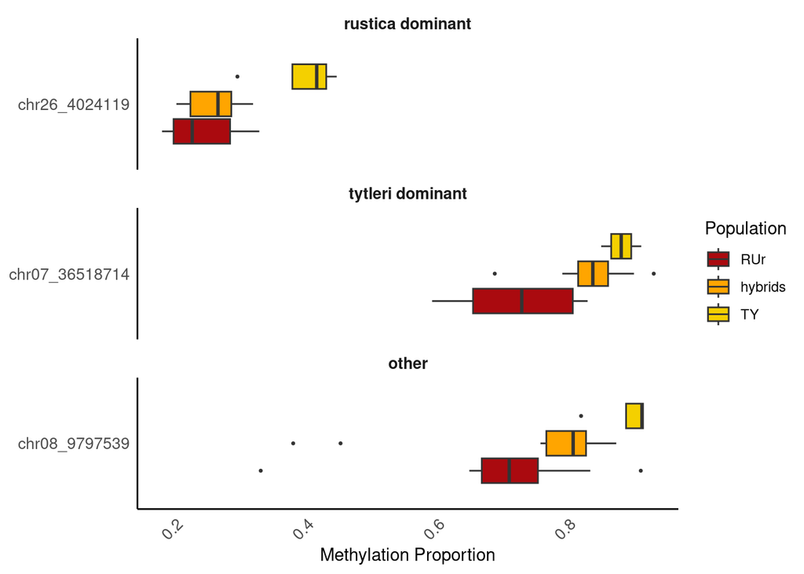

```r
final_results_long <- final_results_long %>% filter(site.id %in% c("chr26_4024119", "chr07_36518714", "chr08_9797539"))


pal <- c("#aa0a0f", #R
         "#FFA500", #RT
         "#f4d000", #T
         "grey") #NA/unknown
names(pal) <- c("RUr", "hybrids", "TY")

sub_plot <- final_results_long %>%
  ggplot(aes(x = site.id, y = methylation)) +
  geom_boxplot(aes(fill = population), outlier.size = 0.5) + # fill by population to distinguish
  # Use facet_wrap to create separate plots for each 'type'
  # The 'scales = "free_y"' combined with 'coord_flip()' ensures that
  # only the site.ids relevant to each facet are shown.
  facet_wrap(~ type, scales = "free_y", ncol = 1) + # Changed ncol to 2
  # Flip the coordinates for better horizontal space for site.id labels
  coord_flip() +
  # Add labels and a title for clarity.
  labs(
    title = "Methylation Proportion of Significant CpG sites",
    x = "Site ID",
    y = "Methylation Proportion",
    fill = "Population"
  ) +
  # Use a minimal theme and remove the plot background for a cleaner look.
  theme_minimal() +
  theme(
    plot.title = element_blank(),
    axis.text.x = element_text(angle = 45, hjust = 1, size=10),
    axis.text.y = element_text(size=10),
    axis.line.x = element_line(),
    axis.line.y = element_line(),
    panel.background = element_blank(),
    panel.grid = element_blank(),
    axis.title.y = element_blank(),
    strip.text = element_text(size = 10, face = "bold")
  ) +
  # Add the custom color palette to the plot
  scale_fill_manual(values = pal)

print(sub_plot)
```

save image

```r
ggsave("/dss/dsslegfs01/pr53da/pr53da-dss-0034/projects/2021_SwallowRRBS/4_RGT_Hybrids/3_methylation_models/RT_hyb/RT_diff/0_Figure3d_RT_boxplots.png", plot = sub_plot, width = 6, height = 3, units = "in", dpi = 500)
```